# Cosa determina il prezzo di uno skipass?

Analisi statistica su 499 comprensori sciistici nel mondo

Alessandro Macchi, Riccardo Mariani, Angel Mendoza, Marco Procopio

# 1 Obiettivo dell’analisi

Il prezzo è la nostra variabile da spiegare; altitudine, Paese, servizi, neve ecc possono essere i fattori esplicativi. Per ragionare in modo ordinato raggruppiamo i candidati in quattro analisi su come il prezzo cambia.

## 1.1 LE quattro analisi

1. **La montagna in sé** — comprensori più grandi e più alti costano di più?
2. **Geografia e ricchezza** — la posizione e la ricchezza del Paese guidano il prezzo?
3. **Servizi e posizionamento** — gli extra (snowpark, sci estivo…) giustificano un sovrapprezzo?
4. **La neve** — più neve significa prezzo più alto?

## 1.2 Librerie

```r
# install.packages("rio")
# install.packages("dplyr")
# install.packages("rcompanion")
# install.packages("ggplot2")
library(rio)
library(dplyr)
library(rcompanion)
library(ggplot2)
```

```r
blue <- "#2c7fb8"
```

# 2 Importazione e pulizia dei dati

*Ski Resorts* (Kaggle): 499 comprensori, 25 variabili (posizione, struttura, servizi, prezzo). Il file viene letto come **Latin-1** perché i nomi dei comprensori contengono caratteri accentati (é, ü, ñ). Un file separato, `snow.csv`, contiene la copertura nevosa mensile del 2022 per coordinata.

```r
resorts <- import("data/resorts.csv", encoding = "Latin-1")

str(resorts)
```

```
## 'data.frame':    499 obs. of  25 variables:
##  $ ID                 : int  1 2 3 4 5 6 7 8 9 10 ...
##  $ Resort             : chr  "Hemsedal" "Geilosiden Geilo" "Golm" "Red Mountain Resort-Rossland" ...
##  $ Latitude           : num  60.9 60.5 47.1 49.1 61.2 ...
##  $ Longitude          : num  8.38 8.21 9.83 -117.85 10.53 ...
##  $ Country            : chr  "Norway" "Norway" "Austria" "Canada" ...
##  $ Continent          : chr  "Europe" "Europe" "Europe" "North America" ...
##  $ Price              : int  46 44 48 60 45 43 61 57 22 20 ...
##  $ Season             : chr  "November - May" "November - April" "December - April" "December - April" ...
##  $ Highest point      : int  1450 1178 2110 2075 1030 960 1980 2700 1385 1554 ...
##  $ Lowest point       : int  620 800 650 1185 195 284 1300 1600 1030 1300 ...
##  $ Beginner slopes    : int  29 18 13 20 33 25 5 10 4 7 ...
##  $ Intermediate slopes: int  10 12 12 50 7 4 0 15 0 1 ...
##  $ Difficult slopes   : int  4 4 1 50 4 11 5 10 0 0 ...
##  $ Total slopes       : int  43 34 26 120 44 40 10 35 4 8 ...
##  $ Longest run        : int  6 2 9 7 6 0 0 13 0 6 ...
##  $ Snow cannons       : int  325 100 123 0 150 40 0 0 0 0 ...
##  $ Surface lifts      : int  15 18 4 2 14 7 5 4 3 4 ...
##  $ Chair lifts        : int  6 6 4 5 3 4 1 6 1 0 ...
##  $ Gondola lifts      : int  0 0 3 1 1 0 0 1 0 0 ...
##  $ Total lifts        : int  21 24 11 8 18 11 6 11 4 4 ...
##  $ Lift capacity      : int  22921 14225 16240 9200 21060 11900 5600 11080 2880 3229 ...
##  $ Child friendly     : chr  "Yes" "Yes" "Yes" "Yes" ...
##  $ Snowparks          : chr  "Yes" "Yes" "No" "Yes" ...
##  $ Nightskiing        : chr  "Yes" "Yes" "No" "Yes" ...
##  $ Summer skiing      : chr  "No" "No" "No" "No" ...
```

```r
nrow(resorts)
```

```
## [1] 499
```

```r
ncol(resorts)
```

```
## [1] 25
```

## 2.1 Pulizia e preparazione

```r
summary(resorts)
```

```
##        ID           Resort             Latitude        Longitude
##  Min.   :  1.0   Length:499         Min.   :-45.05   Min.   :-149.741
##  1st Qu.:125.5   Class :character   1st Qu.: 43.67   1st Qu.:   1.381
##  Median :250.0   Mode  :character   Median : 46.35   Median :   8.206
##  Mean   :250.0                      Mean   : 43.21   Mean   :  -6.007
##  3rd Qu.:374.5                      3rd Qu.: 47.33   3rd Qu.:  12.429
##  Max.   :499.0                      Max.   : 67.78   Max.   : 176.877
##    Country           Continent             Price           Season
##  Length:499         Length:499         Min.   :  0.00   Length:499
##  Class :character   Class :character   1st Qu.: 36.00   Class :character
##  Mode  :character   Mode  :character   Median : 45.00   Mode  :character
##                                        Mean   : 48.72
##                                        3rd Qu.: 54.00
##                                        Max.   :141.00
##  Highest point   Lowest point  Beginner slopes  Intermediate slopes
##  Min.   : 163   Min.   :  36   Min.   :  0.00   Min.   :  0.00
##  1st Qu.:1594   1st Qu.: 800   1st Qu.: 10.00   1st Qu.: 12.00
##  Median :2175   Median :1121   Median : 18.00   Median : 25.00
##  Mean   :2161   Mean   :1201   Mean   : 31.82   Mean   : 37.92
##  3rd Qu.:2700   3rd Qu.:1500   3rd Qu.: 30.00   3rd Qu.: 45.00
##  Max.   :3914   Max.   :3286   Max.   :312.00   Max.   :239.00
##  Difficult slopes  Total slopes     Longest run      Snow cannons
##  Min.   :  0.00   Min.   :  1.00   Min.   : 0.000   Min.   :   0.0
##  1st Qu.:  3.00   1st Qu.: 30.00   1st Qu.: 0.000   1st Qu.:   0.0
##  Median :  9.00   Median : 55.00   Median : 3.000   Median :  15.0
##  Mean   : 16.16   Mean   : 85.91   Mean   : 3.545   Mean   : 179.1
##  3rd Qu.: 21.00   3rd Qu.:100.00   3rd Qu.: 6.000   3rd Qu.: 180.0
##  Max.   :126.00   Max.   :600.00   Max.   :16.000   Max.   :2383.0
##  Surface lifts    Chair lifts     Gondola lifts     Total lifts
##  Min.   : 0.00   Min.   : 0.000   Min.   : 0.000   Min.   :  0.00
##  1st Qu.: 3.00   1st Qu.: 3.000   1st Qu.: 0.000   1st Qu.: 10.00
##  Median : 7.00   Median : 6.000   Median : 1.000   Median : 15.00
##  Mean   :11.28   Mean   : 9.721   Mean   : 3.259   Mean   : 24.26
##  3rd Qu.:14.00   3rd Qu.:11.500   3rd Qu.: 4.000   3rd Qu.: 26.00
##  Max.   :89.00   Max.   :74.000   Max.   :40.000   Max.   :174.00
##  Lift capacity    Child friendly      Snowparks         Nightskiing
##  Min.   :     0   Length:499         Length:499         Length:499
##  1st Qu.: 11645   Class :character   Class :character   Class :character
##  Median : 18510   Mode  :character   Mode  :character   Mode  :character
##  Mean   : 31651
##  3rd Qu.: 32829
##  Max.   :252280
##  Summer skiing
##  Length:499
##  Class :character
##  Mode  :character
##
##
##
```

```r
table(resorts$Continent)
```

```
##
##          Asia        Europe North America       Oceania South America
##            24           360            98            10             7
```

Il campione è prevalentemente europeo (360 su 499) e nordamericano (98); Oceania (10) e Sud America (7) sono sottorappresentati.

## 2.2 Individuare i valori mancanti

```r
apply(resorts, 2, function(x) sum(is.na(x)))
```

```
##                  ID              Resort            Latitude           Longitude
##                   0                   0                   0                   0
##             Country           Continent               Price              Season
##                   0                   0                   0                   0
##       Highest point        Lowest point     Beginner slopes Intermediate slopes
##                   0                   0                   0                   0
##    Difficult slopes        Total slopes         Longest run        Snow cannons
##                   0                   0                   0                   0
##       Surface lifts         Chair lifts       Gondola lifts         Total lifts
##                   0                   0                   0                   0
##       Lift capacity      Child friendly           Snowparks         Nightskiing
##                   0                   0                   0                   0
##       Summer skiing
##                   0
```

Ora c’è la ricera degli NA, vista la grande quantità di zeri

```r
colonne_num <- sapply(resorts, is.numeric)
apply(resorts[, colonne_num], 2, function(x) sum(x == 0, na.rm = TRUE))
```

```
##                  ID            Latitude           Longitude               Price
##                   0                   0                   0                   9
##       Highest point        Lowest point     Beginner slopes Intermediate slopes
##                   0                   0                   4                   5
##    Difficult slopes        Total slopes         Longest run        Snow cannons
##                  35                   0                 212                 226
##       Surface lifts         Chair lifts       Gondola lifts         Total lifts
##                  18                  14                 175                   1
##       Lift capacity
##                   3
```

**Interpretazione degli zeri trovati:**

- `Price`: 9 zeri → impossibile (uno skipass non può essere gratis) → **NA mascherati**
- `Total lifts`: 1 zero → impossibile (un comprensorio ha bisogno di impianti) → **NA mascherato**
- `Beginner / Intermediate / Difficult slopes`: plausibile (un comprensorio può non avere un livello di difficoltà)
- `Snow cannons` (226), `Gondola lifts` (175): plausibile (i piccoli comprensori spesso ne sono privi)
- `Longest run` (212): sospetto ma ambiguo, per ora lo manteniamo

```r
#conversione degli zeri in NA
resorts$Price <- ifelse(resorts$Price == 0, NA, resorts$Price)
resorts$`Total lifts` <- ifelse(resorts$`Total lifts` == 0, NA, resorts$`Total lifts`)

#conversione del prezzo dello skipass da EUR a USD (1 EUR = 1,053 USD)
EUR_USD_2022 <- 1.053
resorts$Price <- resorts$Price * EUR_USD_2022

apply(resorts, 2, function(x) sum(is.na(x)))
```

```
##                  ID              Resort            Latitude           Longitude
##                   0                   0                   0                   0
##             Country           Continent               Price              Season
##                   0                   0                   9                   0
##       Highest point        Lowest point     Beginner slopes Intermediate slopes
##                   0                   0                   0                   0
##    Difficult slopes        Total slopes         Longest run        Snow cannons
##                   0                   0                   0                   0
##       Surface lifts         Chair lifts       Gondola lifts         Total lifts
##                   0                   0                   0                   1
##       Lift capacity      Child friendly           Snowparks         Nightskiing
##                   0                   0                   0                   0
##       Summer skiing
##                   0
```

## 2.3 La variabile `Season`

Il campo grezzo contiene decine di stringhe disordinate (intervalli di mesi) più 27 voci marcate come `"Unknown"`.

```r
table(resorts$Season)
```

```
##
##                                               April
##                                                   5
##                                            December
##                                                   2
##                                    December - April
##                                                 220
## December - April, June - August, October - November
##                                                   1
##                                    December - March
##                                                  40
##                                      December - May
##                                                   7
##                                                July
##                                                   1
##                                        July - April
##                                                   1
##                                      July - October
##                                                   1
##                                    July - September
##                                                   1
##                                          June - May
##                                                   1
##                                      June - October
##                                                  10
##                                    June - September
##                                                   4
##                                               March
##                                                   2
##                                                 May
##                                                   1
##                                       May - October
##                                                   1
##                                     May - September
##                                                   1
##                                    November - April
##                                                 110
##                                     November - June
##                                                   1
##                                    November - March
```

[output cut: 8 more lines]

```
##                                                   2
##                                       October - May
##                                                   7
##  October - November, December - May, June - October
##                                                   1
##                                   September - April
##                                                   1
##                                    September - June
##                                                   2
##                                     September - May
##                                                   2
##                                             Unknown
##                                                  27
##                                          Year-round
##                                                   4
```

```r
length(unique(resorts$Season))
```

```
## [1] 31
```

Raggruppiamo i mesi nella stagione effettiva:

- **Winter_Only**: stagione invernale (nov–mag)
- **Summer_Only**: solo mesi estivi (ghiacciai)
- **Multi_Season**: aperto sia in inverno sia in estate
- **Year_Round**: aperto tutto l’anno
- **NA**: in precedenza “Unknown”

```r
# Definizione dei valori per ciascuna categoria
seasons_winter <- c("December - April", "November - April", "December - March",
                    "November - May", "October - May", "December - May",
                    "October - April", "April", "October - June", "September - June",
                    "September - May", "March", "December", "July - April",
                    "November - June", "September - April", "November - March")

seasons_summer <- c("June - October", "June - September", "July - September",
                    "May - September", "July", "May - October", "May",
                    "July - October")

seasons_multi <- c("November - May, June - August",
                   "December - April, June - August, October - November",
                   "October - November, December - May, June - October")

resorts$Season <- ifelse(resorts$Season == "Unknown", NA,
                  ifelse(resorts$Season == "Year-round", "Year_Round",
                  ifelse(resorts$Season %in% seasons_multi, "Multi_Season",
                  ifelse(resorts$Season %in% seasons_summer, "Summer_Only",
                  ifelse(resorts$Season %in% seasons_winter, "Winter_Only", NA)))))

table(resorts$Season, useNA = "ifany")
```

```
##
## Multi_Season  Summer_Only  Winter_Only   Year_Round         <NA>
##            4           20          443            4           28
```

## 2.4 Variabili derivate

Creiamo quelle che riteniamo utili: il **dislivello** (`Vertical_Drop`) e una **fascia di altitudine** (`Altitude_Band`), che catturano l’idea di “quanta montagna c’è” più direttamente delle colonne grezze.

```r
resorts <- mutate(resorts, Vertical_Drop = `Highest point` - `Lowest point`)

resorts$Altitude_Band <- cut(resorts$`Highest point`,
                             breaks = c(0, 1500, 2500, 3500, 5000),
                             labels = c("Low", "Medium", "High", "Very_High"))

table(resorts$Altitude_Band)
```

```
##
##       Low    Medium      High Very_High
##       111       221       147        20
```

## 2.5 Caricamento del dataset esterno

Per testare l’analisi 2 servono dati economici a livello di Paese che il file dei comprensori non contiene. Aggiungiamo un indicatore della **Banca Mondiale (2022)**:

- **PIL pro capite**

> Il fattore di conversione **PPP** della Banca Mondiale è un *conversion factor* in unità di valuta locale per dollaro internazionale, quindi i suoi valori tra Paesi riflettono la denominazione della valuta.

### 2.5.1 Preparazione del file della Banca Mondiale

Si tiene Paese + valore 2022, allinea i nomi dei Paesi a quelli del dataset dei comprensori e scrive un file ordinato a due colonne.

```r
clean_worldbank <- function(path_raw, value_name, year = "2022") {
  raw <- import(path_raw, skip = 4, header = TRUE)   # salta le 4 righe di preambolo

  clean <- data.frame(
    Country = raw[["Country Name"]],
    value   = as.numeric(raw[[year]]),
    stringsAsFactors = FALSE
  )
  names(clean)[2] <- value_name

  rename_map <- c(
    "Czechia"             = "Czech Republic",
    "Korea, Rep."         = "South Korea",
    "Russian Federation"  = "Russia",
    "Slovak Republic"     = "Slovakia",
    "Turkiye"             = "Turkey",
    "Iran, Islamic Rep."  = "Iran",
    "Kyrgyz Republic"     = "Kyrgyzstan"
  )
  to_fix <- clean$Country %in% names(rename_map)
  clean$Country[to_fix] <- rename_map[clean$Country[to_fix]]

  clean
}

gdp_clean <- clean_worldbank("data/gdp_per_capita_raw.csv", "GDP_per_capita")
export(gdp_clean, "data/gdp_per_capita_clean.csv")
```

```r
gdp <- import("data/gdp_per_capita_clean.csv")

resorts <- merge(resorts, gdp, by = "Country", all.x = TRUE)

#qui i paesi che non hanno trovato corrispondenza
unique(resorts$Country[is.na(resorts$GDP_per_capita)])
```

```
## character(0)
```

L’allineamento dei nomi è gestito da `rename_map`. Dopo il merge ogni Paese ha il valore del PIL pro capite.

# 3 Panoramica descrittiva

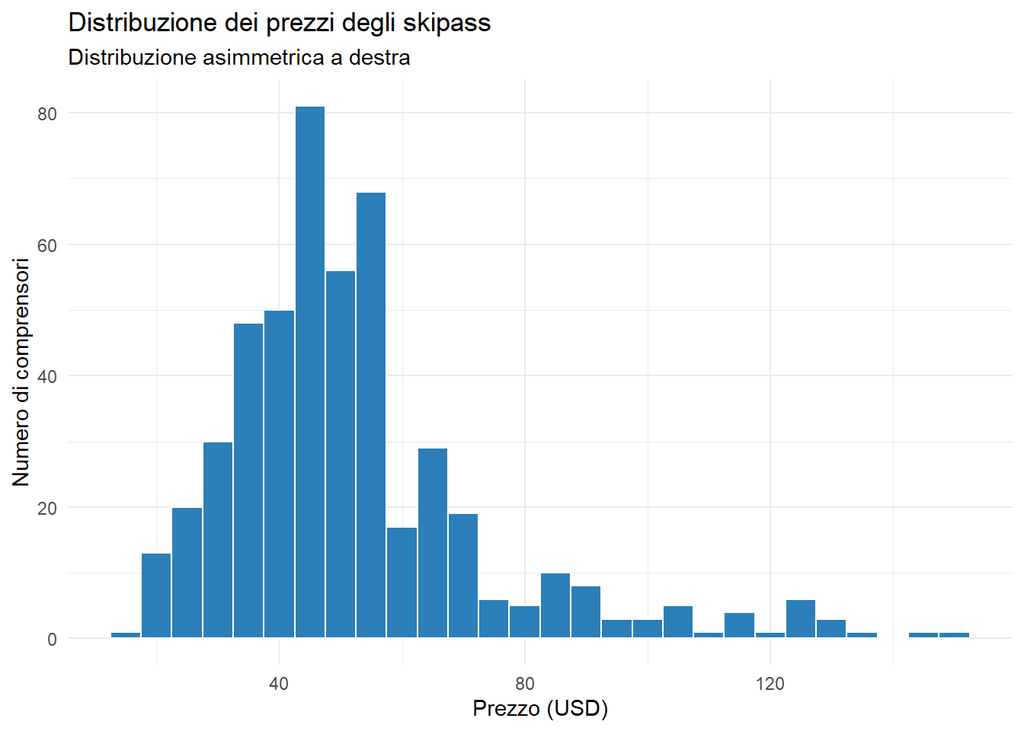

```r
p_price <- ggplot(filter(resorts, !is.na(Price)), aes(x = Price)) +
  geom_histogram(binwidth = 5, fill = blue, colour = "white") +
  labs(title = "Distribuzione dei prezzi degli skipass",
       subtitle = "Distribuzione asimmetrica a destra",
       x = "Prezzo (USD)", y = "Numero di comprensori") +
  theme_minimal()

p_price
```

La **media (~52 $) supera la mediana (48 $)** → distribuzione **asimmetrica a destra**: pochi comprensori premium tirano su il valore medio. La maggioranza dei prezzi si concentra tra 32 e 63 $.

# 4 Analisi 1 — La montagna

**Ipotesi:** i comprensori più grandi/alti costano di più (più terreno, più infrastrutture da mantenere).

## 4.1 Test di correlazione

- H0: correlazione = 0 (nessuna relazione lineare)
- H1: correlazione ≠ 0

```r
# Prezzo vs altitudine massima
cor.test(resorts$`Highest point`, resorts$Price, use = "pairwise.complete.obs")
```

```
##
##  Pearson's product-moment correlation
##
## data:  resorts$`Highest point` and resorts$Price
## t = 9.7934, df = 488, p-value < 2.2e-16
## alternative hypothesis: true correlation is not equal to 0
## 95 percent confidence interval:
##  0.3284974 0.4767516
## sample estimates:
##       cor
## 0.4052857
```

```r
# Prezzo vs numero totale di piste
cor.test(resorts$`Total slopes`, resorts$Price, use = "pairwise.complete.obs")
```

```
##
##  Pearson's product-moment correlation
##
## data:  resorts$`Total slopes` and resorts$Price
## t = 7.1011, df = 488, p-value = 4.398e-12
## alternative hypothesis: true correlation is not equal to 0
## 95 percent confidence interval:
##  0.2235080 0.3841972
## sample estimates:
##       cor
## 0.3060306
```

```r
# Prezzo vs numero totale di impianti
cor.test(resorts$`Total lifts`, resorts$Price, use = "pairwise.complete.obs")
```

```
##
##  Pearson's product-moment correlation
##
## data:  resorts$`Total lifts` and resorts$Price
## t = 2.2946, df = 487, p-value = 0.02218
## alternative hypothesis: true correlation is not equal to 0
## 95 percent confidence interval:
##  0.0148856 0.1903480
## sample estimates:
##       cor
## 0.1034214
```

```r
# Prezzo vs dislivello
cor.test(resorts$Vertical_Drop, resorts$Price, use = "pairwise.complete.obs")
```

```
##
##  Pearson's product-moment correlation
##
## data:  resorts$Vertical_Drop and resorts$Price
## t = 3.7949, df = 488, p-value = 0.0001663
## alternative hypothesis: true correlation is not equal to 0
## 95 percent confidence interval:
##  0.08195443 0.25407810
## sample estimates:
##      cor
## 0.169307
```

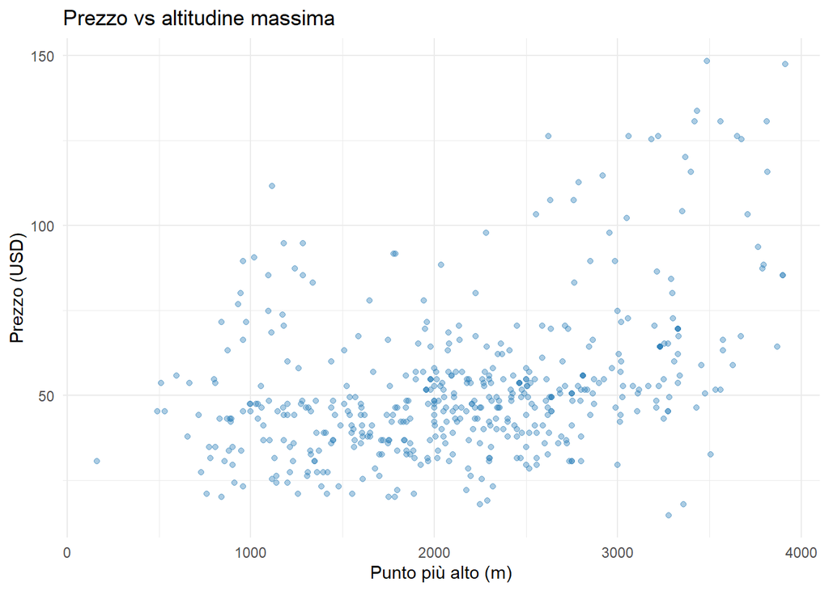

```r
p_alt <- ggplot(filter(resorts, !is.na(Price)),
                aes(x = `Highest point`, y = Price)) +
  geom_point(alpha = 0.4, colour = blue) +
  labs(title = "Prezzo vs altitudine massima",
       x = "Punto più alto (m)", y = "Prezzo (USD)") +
  theme_minimal()

p_alt
```

**Risultati:**

- `Highest point`: r ≈ 0,41, p < 0,001 → positiva moderata
- `Total slopes`: r ≈ 0,31, p < 0,001 → positiva moderata
- `Total lifts`: r ≈ 0,10, p ≈ 0,02 → debole ma significativa
- `Vertical_Drop`: r ≈ 0,17, p < 0,001 → debole ma significativa

Predittore singolo più forte: **l’altitudine massima**.

## 4.2 ANOVA: prezzo per fascia di altitudine

- H0: prezzo medio uguale tra le fasce di altitudine
- H1: almeno una fascia differisce

```r
anova_altitude <- aov(Price ~ Altitude_Band, data = resorts)
summary(anova_altitude)
```

```
##                Df Sum Sq Mean Sq F value Pr(>F)
## Altitude_Band   3  47933   15978   41.21 <2e-16 ***
## Residuals     486 188412     388
## ---
## Signif. codes:  0 '***' 0.001 '**' 0.01 '*' 0.05 '.' 0.1 ' ' 1
## 9 osservazioni eliminate a causa di valori mancanti
```

```r
TukeyHSD(anova_altitude)
```

```
##   Tukey multiple comparisons of means
##     95% family-wise confidence level
##
## Fit: aov(formula = Price ~ Altitude_Band, data = resorts)
##
## $Altitude_Band
##                        diff       lwr       upr     p adj
## Medium-Low        0.5458211 -5.408629  6.500271 0.9953517
## High-Low         14.5770951  8.123106 21.031085 0.0000001
## Very_High-Low    42.7643587 30.416949 55.111769 0.0000000
## High-Medium      14.0312740  8.569087 19.493461 0.0000000
## Very_High-Medium 42.2185376 30.359362 54.077713 0.0000000
## Very_High-High   28.1872636 16.069568 40.304959 0.0000000
```

## 4.3 Conclusione preliminare — analisi 1

> L’altitudine massima e il numero di piste sono legati positivamente al prezzo, ma solo in modo moderato: “più grande = più caro” è solo una parte della storia. Il divario tra la fascia “Very High” e la “Low” arriva a ~43 $.

# 5 analisi 2 — Geografia e ricchezza

**Ipotesi:** i prezzi variano per regione a causa del contesto economico di ogni Paese (potere d’acquisto, costo della vita, mercato turistico).

## 5.1 Prezzo per continente

```r
resorts %>%
  group_by(Continent) %>%
  summarise(
    N       = n(),
    Media   = round(mean(Price, na.rm = TRUE), 1),
    Mediana = round(median(Price, na.rm = TRUE), 1),
    DS      = round(sd(Price, na.rm = TRUE), 1)
  )
```

| Continent | N | Media | Mediana | DS |
| --- | --- | --- | --- | --- |
| Asia | 24 | 41.2 | 43.2 | 11.7 |
| Europe | 360 | 44.1 | 45.3 | 11.4 |
| North America | 98 | 81.9 | 73.7 | 26.9 |
| Oceania | 10 | 74.1 | 77.9 | 15.7 |
| South America | 7 | 59.7 | 60.0 | 7.6 |

## 5.2 ANOVA: prezzo per continente

- H0: il prezzo medio è uguale in tutti i continenti
- H1: almeno un continente ha un prezzo medio significativamente diverso

```r
anova_continent <- aov(Price ~ Continent, data = resorts)
summary(anova_continent)
```

```
##              Df Sum Sq Mean Sq F value Pr(>F)
## Continent     4 115926   28981   116.7 <2e-16 ***
## Residuals   485 120419     248
## ---
## Signif. codes:  0 '***' 0.001 '**' 0.01 '*' 0.05 '.' 0.1 ' ' 1
## 9 osservazioni eliminate a causa di valori mancanti
```

### 5.2.1 Cosa ci dice l’analisi

I prezzi **non sono uguali** tra i continenti — le differenze sono ampie e consistenti.

Confrontando ogni continente con l’**Europa** (riferimento, 360 comprensori):

[output not shown]

> **Messaggio chiave:** il Nord America è in una categoria a sé — uno skipass lì costa quasi il **doppio** rispetto a Europa e Asia. È il divario più grande trovato nell’intero studio.

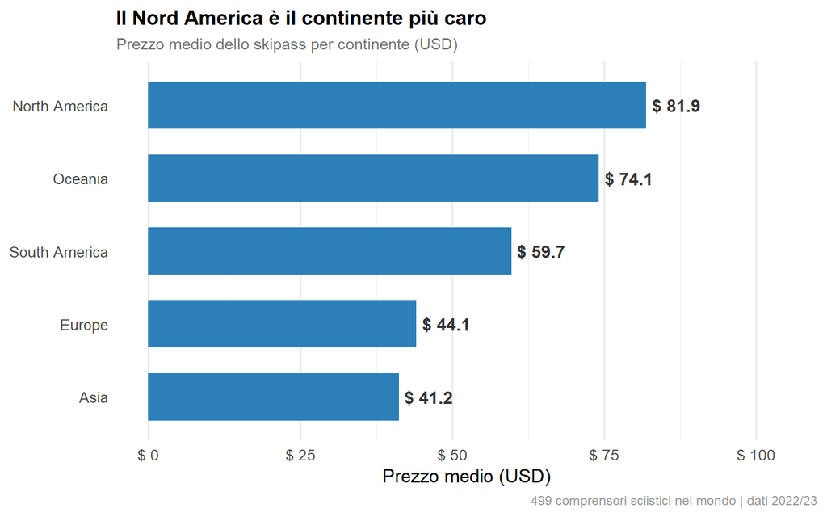

```r
cont_summary <- resorts %>%
  filter(!is.na(Price), !is.na(Continent)) %>%
  group_by(Continent) %>%
  summarise(Prezzo_medio = round(mean(Price, na.rm = TRUE), 1), .groups = "drop")

ggplot(cont_summary,
       aes(x = reorder(Continent, Prezzo_medio), y = Prezzo_medio)) +
  geom_col(fill = blue, width = 0.65) +
  geom_text(aes(label = paste0("$ ", Prezzo_medio)),
            hjust = -0.12, fontface = "bold", size = 4.2, colour = "gray20") +
  coord_flip() +
  scale_y_continuous(limits = c(0, max(cont_summary$Prezzo_medio) * 1.28),
                     labels = function(x) paste0("$ ", x)) +
  labs(
    title    = "Il Nord America è il continente più caro",
    subtitle = "Prezzo medio dello skipass per continente (USD)",
    x        = NULL,
    y        = "Prezzo medio (USD)",
    caption  = "499 comprensori sciistici nel mondo | dati 2022/23"
  ) +
  theme_minimal(base_size = 13) +
  theme(
    panel.grid.major.y = element_blank(),
    plot.title         = element_text(face = "bold", size = 14),
    plot.subtitle      = element_text(colour = "gray45", size = 11),
    plot.caption       = element_text(colour = "gray60", size = 9)
  )
```

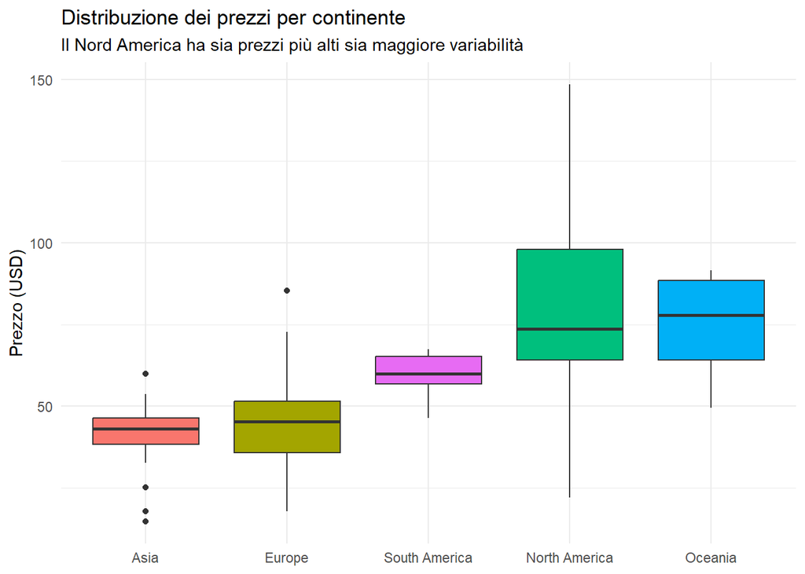

```r
cont_data <- filter(resorts, !is.na(Price) & !is.na(Continent))
ggplot(cont_data,
       aes(x = reorder(Continent, Price, FUN = median),
           y = Price, fill = Continent)) +
  geom_boxplot(show.legend = FALSE) +
  labs(title = "Distribuzione dei prezzi per continente",
       subtitle = "Il Nord America ha sia prezzi più alti sia maggiore variabilità",
       x = NULL, y = "Prezzo (USD)") +
  theme_minimal()
```

## 5.3 Correlazione con la ricchezza nazionale

I prezzi riflettono quanto è ricco il Paese? Sia `Price` sia il PIL pro capite sono espressi in dollari USA, quindi il confronto avviene in un’unica valuta.

- H0: nessuna relazione lineare tra PIL pro capite e prezzo
- H1: esiste una relazione lineare tra PIL pro capite e prezzo

```r
cor.test(resorts$GDP_per_capita, resorts$Price, use = "pairwise.complete.obs")
```

```
##
##  Pearson's product-moment correlation
##
## data:  resorts$GDP_per_capita and resorts$Price
## t = 11.052, df = 488, p-value < 2.2e-16
## alternative hypothesis: true correlation is not equal to 0
## 95 percent confidence interval:
##  0.3736601 0.5155790
## sample estimates:
##      cor
## 0.447432
```

# 6 analisi 3 — Servizi e posizionamento commerciale

**Ipotesi:** i servizi aggiuntivi (snowpark, sci notturno, sci estivo, strutture per famiglie) impongono un sovrapprezzo perché rivolti a segmenti di clientela disposti a pagare di più.

## 6.1 Distribuzione delle variabili di servizio

```r
table(resorts$Snowparks)
```

```
##
##  No Yes
## 121 378
```

```r
table(resorts$Nightskiing)
```

```
##
##  No Yes
## 295 204
```

```r
table(resorts$`Summer skiing`)
```

```
##
##  No Yes
## 470  29
```

```r
table(resorts$`Child friendly`)
```

```
##
##  No Yes
##   4 495
```

## 6.2 T-test: prezzo per ciascun servizio

**Ipotesi (per ciascun servizio):**

- H0: il prezzo medio è uguale per i comprensori con vs senza il servizio
- H1: il prezzo medio differisce tra comprensori con vs senza il servizio

```r
# Snowpark
t.test(resorts$Price[resorts$Snowparks == "Yes"],
       resorts$Price[resorts$Snowparks == "No"])
```

```
##
##  Welch Two Sample t-test
##
## data:  resorts$Price[resorts$Snowparks == "Yes"] and resorts$Price[resorts$Snowparks == "No"]
## t = 4.4291, df = 202.14, p-value = 1.549e-05
## alternative hypothesis: true difference in means is not equal to 0
## 95 percent confidence interval:
##   5.435818 14.159139
## sample estimates:
## mean of x mean of y
##  54.54540  44.74792
```

```r
# Sci notturno
t.test(resorts$Price[resorts$Nightskiing == "Yes"],
       resorts$Price[resorts$Nightskiing == "No"])
```

```
##
##  Welch Two Sample t-test
##
## data:  resorts$Price[resorts$Nightskiing == "Yes"] and resorts$Price[resorts$Nightskiing == "No"]
## t = -0.63665, df = 479.23, p-value = 0.5247
## alternative hypothesis: true difference in means is not equal to 0
## 95 percent confidence interval:
##  -5.055719  2.581270
## sample estimates:
## mean of x mean of y
##  51.51881  52.75603
```

```r
# Sci estivo
t.test(resorts$Price[resorts$`Summer skiing` == "Yes"],
       resorts$Price[resorts$`Summer skiing` == "No"])
```

```
##
##  Welch Two Sample t-test
##
## data:  resorts$Price[resorts$`Summer skiing` == "Yes"] and resorts$Price[resorts$`Summer skiing` == "No"]
## t = 4.1262, df = 33.001, p-value = 0.0002348
## alternative hypothesis: true difference in means is not equal to 0
## 95 percent confidence interval:
##   6.930125 20.411407
## sample estimates:
## mean of x mean of y
##  65.13557  51.46481
```

```r
# Adatto ai bambini
t.test(resorts$Price[resorts$`Child friendly` == "Yes"],
       resorts$Price[resorts$`Child friendly` == "No"])
```

```
##
##  Welch Two Sample t-test
##
## data:  resorts$Price[resorts$`Child friendly` == "Yes"] and resorts$Price[resorts$`Child friendly` == "No"]
## t = 0.3471, df = 3.0432, p-value = 0.7511
## alternative hypothesis: true difference in means is not equal to 0
## 95 percent confidence interval:
##  -33.23018  41.43968
## sample estimates:
## mean of x mean of y
##  52.27950  48.17475
```

## 6.3 ANOVA: prezzo per stagionalità

`Year_Round` e `Multi_Season` sono minuscole (4 ciascuna), quindi questo è esplorativo.

- H0: prezzo medio uguale tra i tipi di stagionalità
- H1: almeno uno differisce

```r
anova_season <- aov(Price ~ Season, data = resorts)
summary(anova_season)
```

```
##              Df Sum Sq Mean Sq F value Pr(>F)
## Season        3   4268  1422.6   2.916 0.0339 *
## Residuals   460 224402   487.8
## ---
## Signif. codes:  0 '***' 0.001 '**' 0.01 '*' 0.05 '.' 0.1 ' ' 1
## 35 osservazioni eliminate a causa di valori mancanti
```

```r
TukeyHSD(anova_season)
```

```
##   Tukey multiple comparisons of means
##     95% family-wise confidence level
##
## Fit: aov(formula = Price ~ Season, data = resorts)
##
## $Season
##                                 diff       lwr        upr     p adj
## Summer_Only-Multi_Season  -2.9788816 -34.30812 28.3503600 0.9948172
## Winter_Only-Multi_Season -15.5450029 -44.14996 13.0599569 0.4991952
## Year_Round-Multi_Season   -3.6855000 -43.95514 36.5841414 0.9953705
## Winter_Only-Summer_Only  -12.5661213 -25.91232  0.7800798 0.0733401
## Year_Round-Summer_Only    -0.7066184 -32.03586 30.6226232 0.9999293
## Year_Round-Winter_Only    11.8595029 -16.74546 40.4644626 0.7086030
```

## 6.4 Conclusione preliminare — analisi 3

> I servizi non sono un sovrapprezzo uniforme. Lo **snowpark** aggiunge un premio reale di **~10 $** (54,6 vs 44,8 $, p < 0,001); **sci notturno** (p ≈ 0,52) e **adatto ai bambini** (p ≈ 0,75, quasi universale: 495/499) non aggiungono nulla. Lo **sci estivo** sembra un premio di +14 $ ma è in realtà un fattore geografico.

# 7 analisi 4 — La neve vera e propria

**Ipotesi:** i comprensori con copertura nevosa naturale più affidabile possono fare pagare di più perché offrono un’esperienza migliore e più prevedibile.

## 7.1 Caricamento del dataset della neve

```r
snow <- import("data/snow.csv")
str(snow)
```

```
## 'data.frame':    820522 obs. of  4 variables:
##  $ Month    : IDate, format: "2022-12-01" "2022-12-01" ...
##  $ Latitude : num  63.1 63.1 63.1 63.1 63.1 ...
##  $ Longitude: num  68.9 69.1 69.4 69.6 69.9 ...
##  $ Snow     : num  95.3 100 100 100 100 ...
```

```r
nrow(snow)
```

```
## [1] 820522
```

```r
# Valori di neve mensili per punto della griglia: Month, Latitude, Longitude, Snow (2022)
```

## 7.2 Aggregazione della neve per comprensorio

I valori di neve stanno su una griglia regolare di 0,25° i cui **centri di cella** cadono su offset di .125 (es. 63.125, 68.875). Agganciamo ogni coordinata di comprensorio al centro della cella che la contiene, aggreghiamo la neve per cella e la colleghiamo a ciascun comprensorio. (Arrotondare al reticolo .0/.25/.5/.75, come fa `round(x * 4) / 4`, disallinea dalla griglia e fa corrispondere solo 125/499 comprensori.)

```r
# La neve sta su una griglia regolare di 0,25° i cui CENTRI di cella cadono
# su offset di .125 (es. 63.125, 68.875), non sul reticolo .0/.25/.5/.75.
# Arrotondare con round(x * 4) / 4 aggancia quindi al reticolo sbagliato e
# fa cadere i punti neve sui confini di arrotondamento .5, così solo 125/499
# comprensori corrispondono. Invece agganciamo ogni coordinata al centro
# della cella di 0,25° che la contiene, così comprensori e neve condividono
# le stesse chiavi.
snap_grid <- function(x) floor(x / 0.25) * 0.25 + 0.125

snow_agg <- snow %>%
  mutate(Lat_key = snap_grid(Latitude),
         Lon_key = snap_grid(Longitude)) %>%
  group_by(Lat_key, Lon_key) %>%
  summarise(Mean_Snow = mean(Snow, na.rm = TRUE),
            Max_Snow = max(Snow, na.rm = TRUE),
            .groups = "drop")

# Aggiungi le stesse chiavi ai comprensori, poi unisci la neve
resorts <- mutate(resorts,
                  Lat_key = snap_grid(Latitude),
                  Lon_key = snap_grid(Longitude))
resorts <- merge(resorts, snow_agg,
                 by = c("Lat_key", "Lon_key"), all.x = TRUE)

sum(!is.na(resorts$Mean_Snow))   # comprensori corrispondenti
```

```
## [1] 477
```

## 7.3 Correlazione: neve vs prezzo

**Ipotesi:**

- H0: nessuna relazione lineare tra copertura nevosa e prezzo
- H1: esiste una relazione lineare tra copertura nevosa e prezzo

```r
cor.test(resorts$Mean_Snow, resorts$Price, use = "pairwise.complete.obs")
```

```
##
##  Pearson's product-moment correlation
##
## data:  resorts$Mean_Snow and resorts$Price
## t = 3.3385, df = 466, p-value = 0.0009099
## alternative hypothesis: true correlation is not equal to 0
## 95 percent confidence interval:
##  0.06306705 0.24014989
## sample estimates:
##       cor
## 0.1528351
```

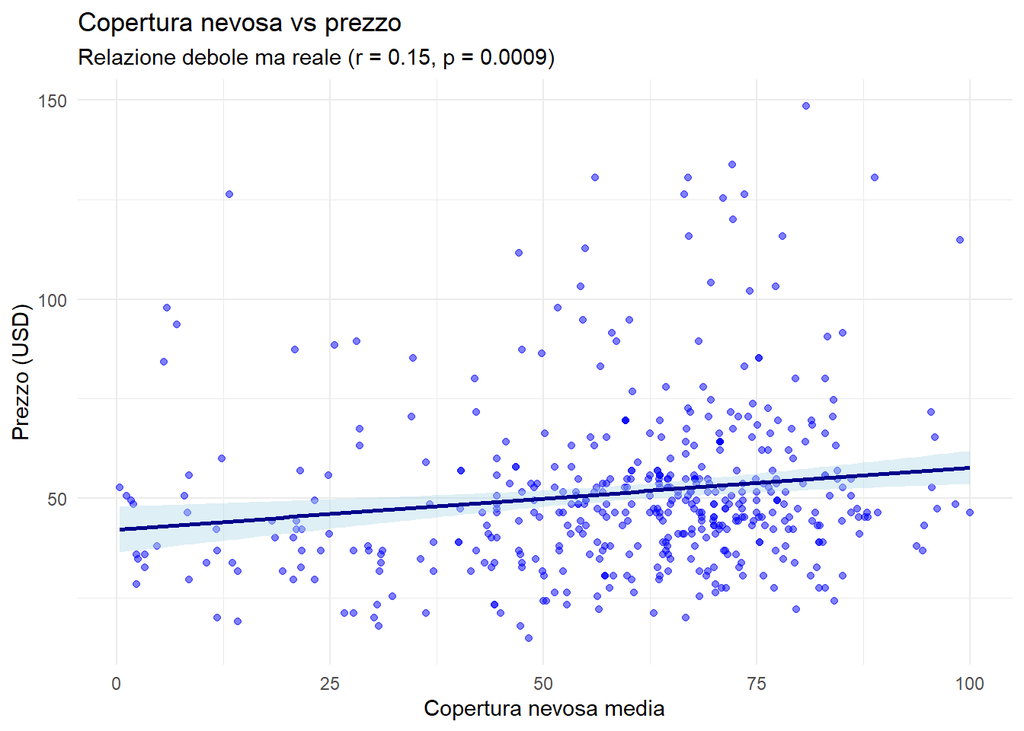

```r
# Neve vs prezzo (analisi 4) - Codice Corretto
snow_plot_data <- filter(resorts, !is.na(Mean_Snow) & !is.na(Price))

p_snow <- ggplot(snow_plot_data, aes(x = Mean_Snow, y = Price)) +
  geom_point(alpha = 0.5, colour = "blue") + # Messo "blue" tra virgolette per evitare errori

  # Questa riga aggiunge la retta di regressione lineare (tendenza)
  geom_smooth(method = "lm", se = TRUE, colour = "darkblue", fill = "lightblue") +

  labs(title = "Copertura nevosa vs prezzo",
       subtitle = "Relazione debole ma reale (r = 0.15, p = 0.0009)",
       x = "Copertura nevosa media", y = "Prezzo (USD)") +
  theme_minimal()

p_snow
```

## 7.4 Conclusione preliminare — analisi 4

> La copertura nevosa segue l’altitudine/latitudine più che il prezzo: la “affidabilità della neve” è in gran parte già incorporata nel prezzo attraverso l’altitudine. Il legame bivariato con il prezzo è debole: più che la neve in sé, a contare è la quota.

# 8 Sintesi: classifica degli analisi

## 8.1 Tabella riepilogativa

```r
# Consolida ogni risultato bivariato delle Sezioni 4-7 in un'unica tabella.
summary_table <- data.frame(
  Factor = c(
    "Altitudine massima (Punto più alto)",
    "Totale piste",
    "Totale impianti",
    "Dislivello",
    "Fascia di altitudine",
    "Continente",
    "Ricchezza nazionale (PIL pro capite)",
    "Presenza snowpark",
    "Sci notturno",
    "Sci estivo",
    "Adatto ai bambini",
    "Stagionalità (Stagione)",
    "Copertura nevosa vs prezzo"
  ),
  Test_Type = c(
    "Correlazione", "Correlazione", "Correlazione", "Correlazione",
    "ANOVA", "ANOVA", "Correlazione",
    "T-test", "T-test", "T-test", "T-test",
    "ANOVA", "Correlazione"
  ),
  Statistic = c(
    0.41, 0.31, 0.10, 0.17,          # valori r
    41.21,                            # F (fascia altitudine)
    116.70,                           # F (continente)
    0.45,                             # r (PIL pro capite)
    4.43, -0.64, 4.13, 0.35,          # valori t (servizi)
    2.92,                             # F (stagione)
    0.15                              # r (neve vs prezzo)
  ),
  P_value = c(
    "<0.001", "<0.001", "0.022", "<0.001",
    "<0.001", "<0.001", "<0.001",
    "<0.001", "0.525", "<0.001", "0.751",
    "0.034", "<0.001"
  ),
  Effect_Strength = c(
    "Moderato", "Moderato", "Debole", "Debole",
    "Moderato", "Forte", "Moderato",
    "Moderato", "Trascurabile", "Moderato", "Trascurabile",
    "Debole", "Debole"
  ),
  Interpretation = c(
    "Comprensori più alti costano di più; predittore numerico singolo più forte (r = 0,41).",
    "Aree sciabili più grandi costano di più, ma il legame è solo moderato (r = 0,31).",
    "Il numero di impianti è appena legato al prezzo (r = 0,10).",
    "Il dislivello ha un legame positivo debole con il prezzo (r = 0,17).",
    "Il prezzo sale tra le fasce di altitudine: Very High è ~43 $ sopra Low.",
    "Il divario più grande di tutti: Nord America ~+38 $ vs Europa.",
    "Nei Paesi più ricchi i prezzi salgono (r = 0,45).",
    "Lo snowpark aggiunge un premio reale di ~10 $ (54,6 vs 44,8).",
    "Nessuna differenza di prezzo tra comprensori con vs senza sci notturno.",
    "Apparente premio di +14 $, ma confuso con emisfero / ghiacciai.",
    "Quasi universale (495/499): nessun contrasto utile, non significativo.",
    "La stagionalità muove appena il prezzo; effetto piccolo e al limite.",
    "Legame positivo debole ma significativo (r = 0,15); risente di collinearità con l'altezza."
  ),
  stringsAsFactors = FALSE
)

summary_table
```

| Factor | Test_Type | Statistic | P_value | Effect_Strength | Interpretation |
| --- | --- | --- | --- | --- | --- |
| Altitudine massima (Punto più alto) | Correlazione | 0.41 | <0.001 | Moderato | Comprensori più alti costano di più; predittore numerico singolo più forte (r = 0,41). |
| Totale piste | Correlazione | 0.31 | <0.001 | Moderato | Aree sciabili più grandi costano di più, ma il legame è solo moderato (r = 0,31). |
| Totale impianti | Correlazione | 0.10 | 0.022 | Debole | Il numero di impianti è appena legato al prezzo (r = 0,10). |
| Dislivello | Correlazione | 0.17 | <0.001 | Debole | Il dislivello ha un legame positivo debole con il prezzo (r = 0,17). |
| Fascia di altitudine | ANOVA | 41.21 | <0.001 | Moderato | Il prezzo sale tra le fasce di altitudine: Very High è ~43 $ sopra Low. |
| Continente | ANOVA | 116.70 | <0.001 | Forte | Il divario più grande di tutti: Nord America ~+38 $ vs Europa. |
| Ricchezza nazionale (PIL pro capite) | Correlazione | 0.45 | <0.001 | Moderato | Nei Paesi più ricchi i prezzi salgono (r = 0,45). |
| Presenza snowpark | T-test | 4.43 | <0.001 | Moderato | Lo snowpark aggiunge un premio reale di ~10 $ (54,6 vs 44,8). |
| Sci notturno | T-test | -0.64 | 0.525 | Trascurabile | Nessuna differenza di prezzo tra comprensori con vs senza sci notturno. |
| Sci estivo | T-test | 4.13 | <0.001 | Moderato | Apparente premio di +14 $, ma confuso con emisfero / ghiacciai. |

[output cut: 3 more lines]

## 8.2 Interpretazione: classifica degli analisi

**Dimensione del comprensorio** (totale piste, r = 0,31, p < 0,001) — le aree più grandi costano di più, in modo moderato.

**analisi deboli.** Numero di impianti (r = 0,10) e dislivello (r = 0,17) sono significativi ma trascurabili; la stagionalità è al limite (F = 2,9, p = 0,034); sci notturno (p = 0,52) e adatto ai bambini (p = 0,75) non mostrano differenze di prezzo.

**Limite.** Sono tutti risultati *bivariati*: ciascuno guarda un fattore alla volta, quindi non sanno districare del tutto le cause confuse tra loro (è il continente, o il fatto che quei comprensori sono anche più grandi e più alti?).

## 8.3 Limiti

- 9 prezzi mascherati come zero (gestiti come NA)
- `Season` ha richiesto una forte ricodifica da 31 valori grezzi
- Oceania (10) e Sud America (7) sottorappresentati
- I prezzi sono una fotografia del 2022/23 → nessuna dimensione temporale
- Correlazione ≠ causalità: associazioni, non meccanismi causali
- Il PIL pro capite è a livello di Paese, non di comprensorio (inferenza ecologica)
- Prezzi convertiti EUR→USD a un unico tasso medio 2022 (1 EUR = 1,053 USD)

# 9 Fonti e riferimenti

- **Ski Resorts**: Pedersen, U. T. (2023). Kaggle. https://www.kaggle.com/datasets/ulrikthygepedersen/ski-resorts
- **Snow Cover**: incluso nel pacchetto Kaggle (`snow.csv`)
- **PIL pro capite**: World Bank Open Data, 2022 (US$ correnti). https://data.worldbank.org/indicator/NY.GDP.PCAP.CD